# FML-Assignment 1

Chandima Attanayake

2024-09-08

## 01. Conduct Basic Descriptive Statistics

```r
# Load necessary libraries

library(dplyr)     # For data manipulation
```

```r
library(psych)     # For psychological and descriptive statistics
library(readr)     # For efficient data import and export
library(tidyverse) # A collection of packages including dplyr, ggplot2, and more
# Load the data
data <- read.csv("//Users/chandimaattanayake/Downloads/Churn.csv")

# View basic descriptive statistics


head(data)    # View the head of the data (first few rows)
```

|  | CallFailures | SubscriptionLength | DataUsage | VoiceMinutes | CustomerSupportCalls | ContractType | MonthlyCharges | RoamingUsage | Churn |
| --- | --- | --- | --- | --- | --- | --- | --- | --- | --- |
| 1 | 16 | 11 | 4.1936070 | 4836.250 | 2 | Monthly | 24.26866 | 2.600714 | 0 |
| 2 | 4 | 9 | 8.4093629 | 1694.926 | 5 | Monthly | 82.48409 | 5.277427 | 1 |
| 3 | 0 | 8 | 0.6541119 | 4384.157 | 3 | Monthly | 52.88977 | 3.170094 | 0 |
| 4 | 9 | 9 | 8.8331384 | 2609.912 | 0 | Monthly | 32.25711 | 3.033796 | 0 |
| 5 | 3 | 8 | 7.2457588 | 2889.617 | 3 | Monthly | 58.24018 | 8.905393 | 0 |
| 6 | 17 | 3 | 0.8084840 | 1206.698 | 1 | Monthly | 31.97728 | 8.853842 | 1 |

```r
tail(data)    # View the tail of the data (last few rows)
```

|  | CallFailures | SubscriptionLength | DataUsage | VoiceMinutes | CustomerSupportCalls | ContractType | MonthlyCharges | RoamingUsage | Churn |
| --- | --- | --- | --- | --- | --- | --- | --- | --- | --- |
| 995 | 9 | 18 | 6.6938689 | 3231.4057 | 4 | Annual | 21.92054 | 7.846210 | 1 |
| 996 | 14 | 13 | 0.3682914 | 220.6486 | 4 | Annual | 33.22040 | 8.031035 | 1 |
| 997 | 18 | 18 | 3.3392797 | 1331.7691 | 4 | Monthly | 25.08640 | 9.778682 | 1 |
| 998 | 11 | 5 | 7.0439535 | 4889.2448 | 4 | Monthly | 26.92161 | 8.391785 | 0 |
| 999 | 17 | 14 | 3.9515069 | 2521.9432 | 5 | Monthly | 73.53721 | 7.639660 | 0 |
| 1000 | 17 | 10 | 0.2560617 | 2507.9017 | 4 | Monthly | 60.24888 | 2.344890 | 0 |

```r
dim(data)     # Check the dimensions of the dataset (number of rows and columns)
```

```
## [1] 1000    9
```

```r
summary(data) # Get a summary of the dataset (min, max, median, etc.)
```

```
##   CallFailures    SubscriptionLength   DataUsage        VoiceMinutes
##  Min.   : 0.000   Min.   : 1.00      Min.   :0.04479   Min.   :   1.913
##  1st Qu.: 5.000   1st Qu.: 6.00      1st Qu.:2.45883   1st Qu.:1392.148
##  Median :10.000   Median :12.00      Median :5.07325   Median :2626.685
##  Mean   : 9.985   Mean   :12.09      Mean   :5.09635   Mean   :2564.964
##  3rd Qu.:16.000   3rd Qu.:18.00      3rd Qu.:7.82260   3rd Qu.:3712.721
##  Max.   :20.000   Max.   :24.00      Max.   :9.99831   Max.   :4998.703
##  CustomerSupportCalls ContractType       MonthlyCharges   RoamingUsage
##  Min.   :0.000        Length:1000        Min.   :20.07   Min.   :0.01345
##  1st Qu.:1.000        Class :character   1st Qu.:37.57   1st Qu.:2.32212
##  Median :2.000        Mode  :character   Median :56.91   Median :4.94221
##  Mean   :2.394                           Mean   :58.42   Mean   :4.95070
##  3rd Qu.:4.000                           3rd Qu.:77.45   3rd Qu.:7.44860
##  Max.   :5.000                           Max.   :99.96   Max.   :9.99680
##      Churn
##  Min.   :0.000
##  1st Qu.:0.000
##  Median :1.000
##  Mean   :0.504
##  3rd Qu.:1.000
##  Max.   :1.000
```

```r
# Check the structure of the dataset (data types, number of factors, etc.)
str(data)
```

```
## 'data.frame':    1000 obs. of  9 variables:
##  $ CallFailures        : int  16 4 0 9 3 17 16 14 6 3 ...
##  $ SubscriptionLength  : int  11 9 8 9 8 3 8 10 10 2 ...
##  $ DataUsage           : num  4.194 8.409 0.654 8.833 7.246 ...
##  $ VoiceMinutes        : num  4836 1695 4384 2610 2890 ...
##  $ CustomerSupportCalls: int  2 5 3 0 3 1 1 4 3 1 ...
##  $ ContractType        : chr  "Monthly" "Monthly" "Monthly" "Monthly" ...
##  $ MonthlyCharges      : num  24.3 82.5 52.9 32.3 58.2 ...
##  $ RoamingUsage        : num  2.6 5.28 3.17 3.03 8.91 ...
##  $ Churn               : int  0 1 0 0 0 1 1 1 0 0 ...
```

```r
# Calculate the mean for numerical variables (excluding NA values)
means <- sapply(data, function(x) if(is.numeric(x)) mean(x, na.rm=TRUE))

# Calculate the median for numerical variables
medians <- sapply(data, function(x) if(is.numeric(x)) median(x, na.rm=TRUE))

# Define a function to calculate the mode
get_mode <- function(x) {
  uniq_vals <- unique(x)
  uniq_vals[which.max(tabulate(match(x, uniq_vals)))]
}


modes <- sapply(data, get_mode) # Calculate the mode for each variable

missing_values <- sapply(data, function(x) sum(is.na(x))) # Check for any missing values in the dataset


# Print the results
print("Means:")
```

```
## [1] "Means:"
```

```r
print(means)
```

```
## $CallFailures
## [1] 9.985
##
## $SubscriptionLength
## [1] 12.093
##
## $DataUsage
## [1] 5.096345
##
## $VoiceMinutes
## [1] 2564.964
##
## $CustomerSupportCalls
## [1] 2.394
##
## $ContractType
## NULL
##
## $MonthlyCharges
## [1] 58.41586
##
## $RoamingUsage
## [1] 4.950701
##
## $Churn
## [1] 0.504
```

```r
print("Medians:")
```

```
## [1] "Medians:"
```

```r
print(medians)
```

```
## $CallFailures
## [1] 10
##
## $SubscriptionLength
## [1] 12
##
## $DataUsage
## [1] 5.073246
##
## $VoiceMinutes
## [1] 2626.685
##
## $CustomerSupportCalls
## [1] 2
##
## $ContractType
## NULL
##
## $MonthlyCharges
## [1] 56.91449
##
## $RoamingUsage
## [1] 4.942205
##
## $Churn
## [1] 1
```

```r
print("Modes:")
```

```
## [1] "Modes:"
```

```r
print(modes)
```

```
##         CallFailures   SubscriptionLength            DataUsage
##                  "9"                 "12"   "4.19360703555867"
##         VoiceMinutes CustomerSupportCalls         ContractType
##   "4836.25042135827"                  "0"            "Monthly"
##       MonthlyCharges         RoamingUsage                Churn
##   "24.2686576396227"   "2.60071393335238"                  "1"
```

```r
print("Missing Values:")
```

```
## [1] "Missing Values:"
```

```r
print(missing_values)
```

```
##         CallFailures   SubscriptionLength            DataUsage
##                    0                    0                    0
##         VoiceMinutes CustomerSupportCalls         ContractType
##                    0                    0                    0
##       MonthlyCharges         RoamingUsage                Churn
##                    0                    0                    0
```

```r
knitr::opts_chunk$set(echo = TRUE)
```

## 02. Interpretation of Descriptive Statistics (in R Markdown)

## Overview

Upon the descritptive analysis, following observations were noted.

- The dataset includes 1000 records with nine variables

**call failure** On average, customers experience about 10 call failures. The most common number of call failures reported is 9 with the mean and median both indicating a high frequency of issues.Therefore, the process related to this service should be revisted.

**Subscription Length** The average subscription length is approximately 12 months, which aligns with the median and mode. This indicates that most customers have a subscription period of around one year.

**Data Usage** Customers use an average of 5.10 GB of data per month. The mode of 4.19 GB suggests that a significant portion of customers use around this amount, even though the the average is slightly higher.

**Monthly Charges** The average monthly charge is about $58.42, with a median of $56.91. The mode of $24.27 suggests that this charge is common among customers, indicating possible tiered pricing.

**Churn** The churn rate is 50%, indicating that roughly half of the customers have churned. The mode of 1 highlights that churn is a common outcome for customers.

**Missing Values** There are no missing values and data set is ready for further analysis

## 03. Select and Compare Two or More Variables

```r
# Load necessary libraries
library(dplyr)
library(ggplot2)

# Select two variables: Data Usage and Churn
selected_data <- dplyr::select(data, DataUsage, Churn)

# Create a summary table for these variables
summary(selected_data)
```

```
##    DataUsage           Churn
##  Min.   :0.04479   Min.   :0.000
##  1st Qu.:2.45883   1st Qu.:0.000
##  Median :5.07325   Median :1.000
##  Mean   :5.09635   Mean   :0.504
##  3rd Qu.:7.82260   3rd Qu.:1.000
##  Max.   :9.99831   Max.   :1.000
```

```r
# Calculate the mean Data Usage for customers who churned vs those who did not
churned_vs_not <- selected_data %>% group_by(Churn) %>% summarize(mean_usage = mean(DataUsage, na.rm=TRUE))

# Display the summary table
print(churned_vs_not)
```

```
## # A tibble: 2 × 2
##   Churn mean_usage
##   <int>      <dbl>
## 1     0       5.04
## 2     1       5.15
```

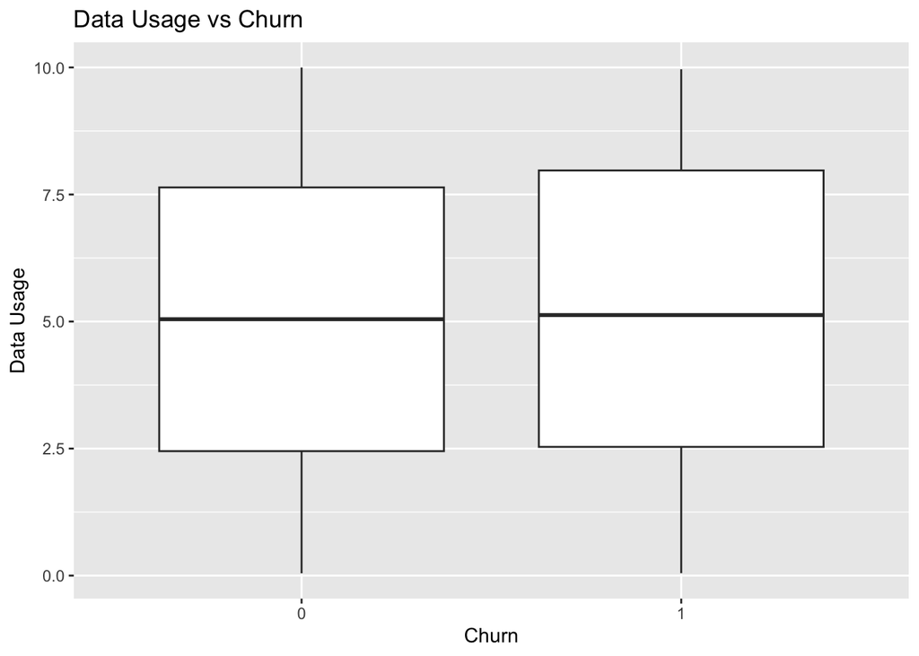

```r
# Create a simple visualization to compare
library(ggplot2)
ggplot(selected_data, aes(x = as.factor(Churn), y = DataUsage)) +
  geom_boxplot() +
  labs(x = "Churn", y = "Data Usage") +
  ggtitle("Data Usage vs Churn")
```

```r
# Check the structure of the dataset to ensure CHURN exists
str(data)
```

```
## 'data.frame':    1000 obs. of  9 variables:
##  $ CallFailures        : int  16 4 0 9 3 17 16 14 6 3 ...
##  $ SubscriptionLength  : int  11 9 8 9 8 3 8 10 10 2 ...
##  $ DataUsage           : num  4.194 8.409 0.654 8.833 7.246 ...
##  $ VoiceMinutes        : num  4836 1695 4384 2610 2890 ...
##  $ CustomerSupportCalls: int  2 5 3 0 3 1 1 4 3 1 ...
##  $ ContractType        : chr  "Monthly" "Monthly" "Monthly" "Monthly" ...
##  $ MonthlyCharges      : num  24.3 82.5 52.9 32.3 58.2 ...
##  $ RoamingUsage        : num  2.6 5.28 3.17 3.03 8.91 ...
##  $ Churn               : int  0 1 0 0 0 1 1 1 0 0 ...
```

```r
# Convert CHURN to a factor if it's not already one
data$Churn <- as.factor(data$Churn)

# Check if the conversion worked
str(data)
```

```
## 'data.frame':    1000 obs. of  9 variables:
##  $ CallFailures        : int  16 4 0 9 3 17 16 14 6 3 ...
##  $ SubscriptionLength  : int  11 9 8 9 8 3 8 10 10 2 ...
##  $ DataUsage           : num  4.194 8.409 0.654 8.833 7.246 ...
##  $ VoiceMinutes        : num  4836 1695 4384 2610 2890 ...
##  $ CustomerSupportCalls: int  2 5 3 0 3 1 1 4 3 1 ...
##  $ ContractType        : chr  "Monthly" "Monthly" "Monthly" "Monthly" ...
##  $ MonthlyCharges      : num  24.3 82.5 52.9 32.3 58.2 ...
##  $ RoamingUsage        : num  2.6 5.28 3.17 3.03 8.91 ...
##  $ Churn               : Factor w/ 2 levels "0","1": 1 2 1 1 1 2 2 2 1 1 ...
```

## 4. Transform a Variable and Generate a Plot Using ggplot

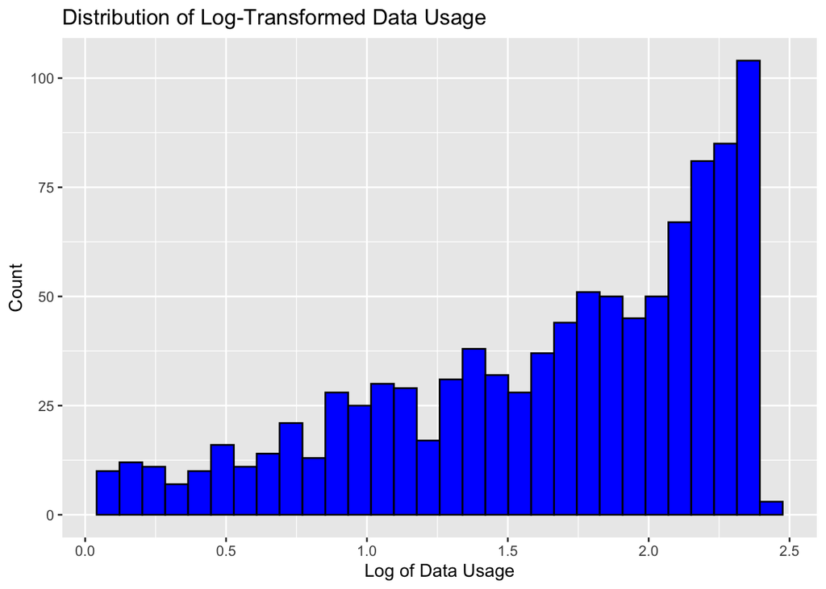

```r
# Load necessary libraries
library(ggplot2)

# Transform the Data Usage variable using log transformation
data$log_dataUsage <- log(data$DataUsage + 1)  # Adding 1 to avoid log(0)

# Plot the transformed variable using ggplot
ggplot(data, aes(x = log_dataUsage)) +  # Changed to plot the transformed variable
  geom_histogram(bins = 30, fill = "blue", color = "black") +
  labs(x = "Log of Data Usage", y = "Count") +
  ggtitle("Distribution of Log-Transformed Data Usage")
```

```r
# Check the structure of the dataset to ensure the variable is created
str(data)
```

```
## 'data.frame':    1000 obs. of  10 variables:
##  $ CallFailures        : int  16 4 0 9 3 17 16 14 6 3 ...
##  $ SubscriptionLength  : int  11 9 8 9 8 3 8 10 10 2 ...
##  $ DataUsage           : num  4.194 8.409 0.654 8.833 7.246 ...
##  $ VoiceMinutes        : num  4836 1695 4384 2610 2890 ...
##  $ CustomerSupportCalls: int  2 5 3 0 3 1 1 4 3 1 ...
##  $ ContractType        : chr  "Monthly" "Monthly" "Monthly" "Monthly" ...
##  $ MonthlyCharges      : num  24.3 82.5 52.9 32.3 58.2 ...
##  $ RoamingUsage        : num  2.6 5.28 3.17 3.03 8.91 ...
##  $ Churn               : Factor w/ 2 levels "0","1": 1 2 1 1 1 2 2 2 1 1 ...
##  $ log_dataUsage       : num  1.647 2.242 0.503 2.286 2.11 ...
```